# Exploratory Data Analysis

STOR 320.02 Group 3

November 07, 2018

# Creator: Marc Rovner

### Q1: What type of shots are most efficient? Which shots are least efficient?

```r
data16 <- sav

shoteff= data16 %>%
  group_by(action_type, shot_type) %>%
  summarise(pct=mean(shot_made_flag))
shoteff$shot_type=as.character(shoteff$shot_type)
shoteff$shot_type=gsub("3PT Field Goal", 3, shoteff$shot_type)
shoteff$shot_type=gsub("2PT Field Goal", 2, shoteff$shot_type)
shoteff
```

```
## # A tibble: 36 x 3
## # Groups:   action_type [?]
##    action_type                    shot_type   pct
##    <chr>                          <chr>     <dbl>
##  1 Alley Oop Dunk Shot            2         0.886
##  2 Alley Oop Layup shot           2         0.634
##  3 Cutting Dunk Shot              2         0.957
##  4 Cutting Finger Roll Layup Shot 2         0.873
##  5 Cutting Layup Shot             2         0.764
##  6 Driving Bank Hook Shot         2         0.675
##  7 Driving Bank Hook Shot         3         0
##  8 Driving Bank shot              2         0.649
##  9 Driving Bank shot              3         0.5
## 10 Driving Dunk Shot              2         0.874
## # ... with 26 more rows
```

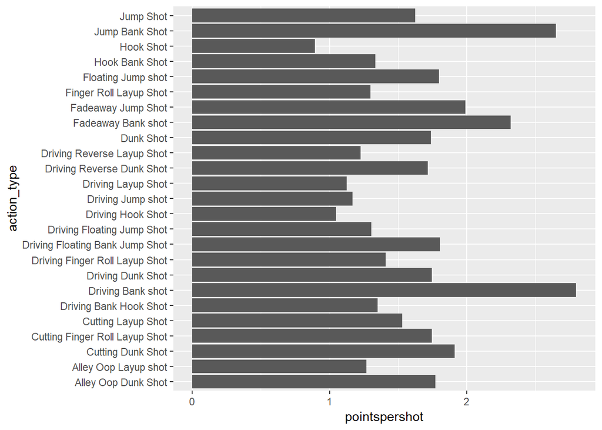

```r
shoteff$pointspershot=shoteff$pct*as.numeric(shoteff$shot_type)
ggplot(shoteff, aes(action_type,pointspershot))+
  geom_bar(stat="identity")+
  coord_flip()
```

```r
#
```

### Q2: Do teams/players like to shoot shots from specific locations at different times?

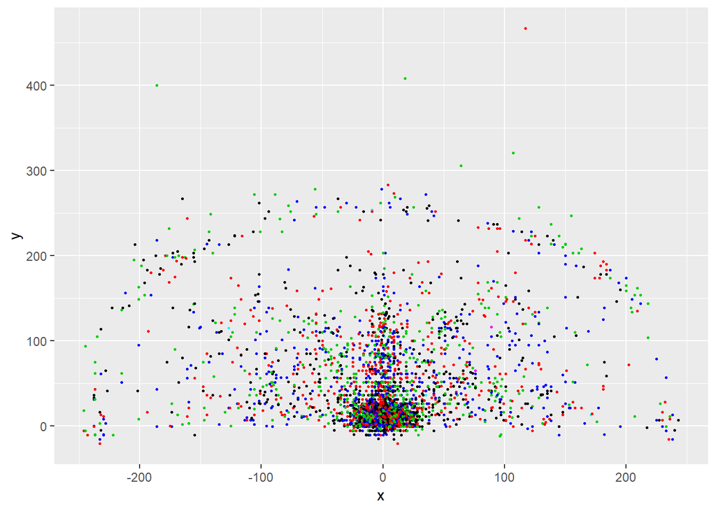

```r
shotlocation=data16 %>%
  filter(team_name=="Golden State Warriors") %>%
  select(x,y,period)
q1location=filter(shotlocation,period==1)
q2location=filter(shotlocation,period==2)
q3location=filter(shotlocation,period==3)
q4location=filter(shotlocation,period==4)
ggplot(shotlocation)+
  geom_point(aes(x,y), size= .5, colour=shotlocation$period, show.legend = TRUE)
```

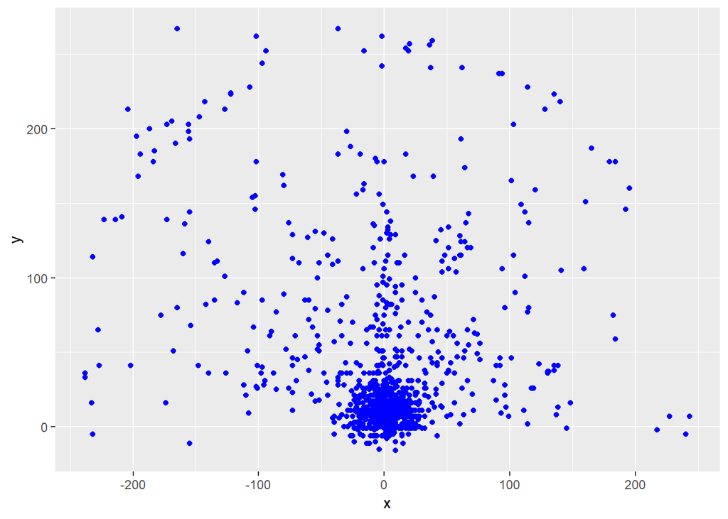

```r
ggplot(q1location) +
  geom_point(aes(x,y), colour='blue')
```

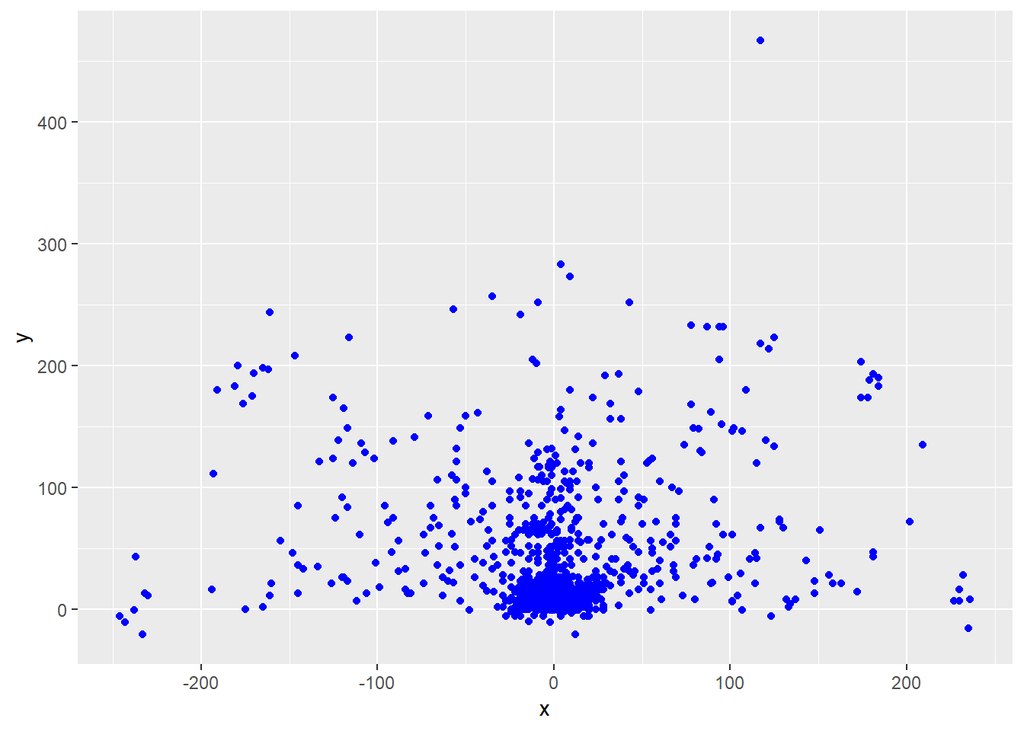

```r
ggplot(q2location) +
  geom_point(aes(x,y), colour='blue')
```

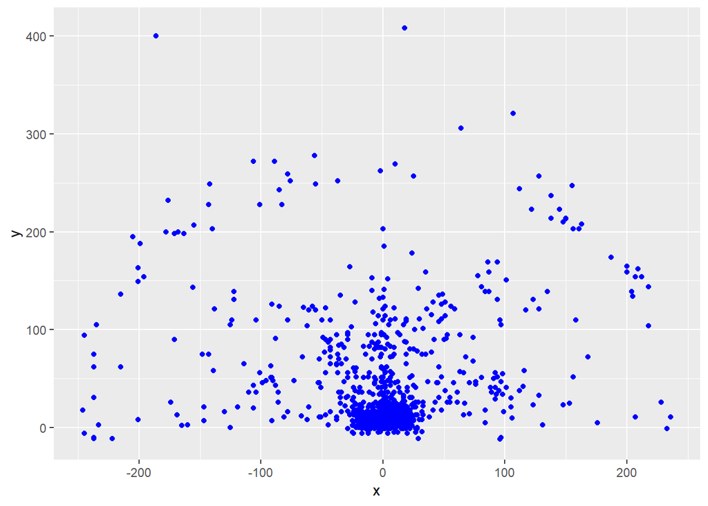

```r
ggplot(q3location) +
  geom_point(aes(x,y), colour='blue')
```

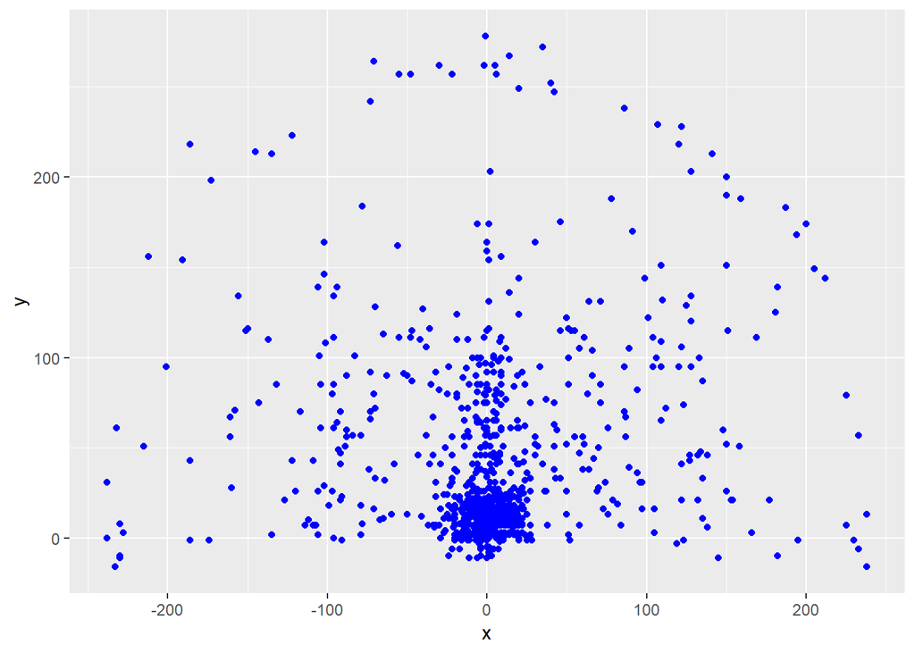

```r
ggplot(q4location) +
  geom_point(aes(x,y), colour='blue')
```

```r
#
```

# Interpreter: Minjoo Son

### Q1: Are there certain shots that players prefer over others? Is there a positive correlation between the preferred shots and their efficiency?

```r
nba <- sav
nba$ticker = 1
dunks <- c('Alley Oop Dunk Shot', 'Cutting Dunk Shot', 'Driving Dunk Shot', 'Driving Reverse Dunk Shot',
           'Dunk Shot')
layups <- c('Alley Oop Layup shot', 'Cutting Finger Roll Layup Shot', 'Driving Reverse Layup Shot',
            'Cutting Layup Shot', 'Driving Layup Shot', 'Finger Roll Layup Shot',
            'Driving Finger Roll Layup Shot', 'Driving Bank shot')
hookshots <- c('Hook Bank Shot', 'Hook Shot', 'Driving Bank Hook Shot', 'Driving Hook Shot')
jumpshots <- c('Driving Floating Bank Jump Shot', 'Driving Jump shot', 'Fadeaway Jump Shot', 'Jump Shot',
               'Driving Floating Jump Shot', 'Floating Jump shot', 'Jump Bank Shot', 'Fadeaway Bank shot')
nba$groups <- with(nba, ifelse(action_type %in% dunks, "dunks",
                               ifelse(action_type %in% layups, "layups",
                                      ifelse(action_type %in% hookshots, "hookshots",
                                             ifelse(action_type %in% jumpshots, "jumpshots", "other")))))
table7 <- as.data.frame(aggregate(nba$shot_made_flag, list(nba$action_type), mean))
table7
```

```
##                            Group.1         x
## 1              Alley Oop Dunk Shot 0.8862681
## 2             Alley Oop Layup shot 0.6342428
## 3                Cutting Dunk Shot 0.9566453
## 4   Cutting Finger Roll Layup Shot 0.8728466
## 5               Cutting Layup Shot 0.7644606
## 6           Driving Bank Hook Shot 0.6723549
## 7                Driving Bank shot 0.6487119
## 8                Driving Dunk Shot 0.8735043
## 9   Driving Finger Roll Layup Shot 0.7041395
## 10 Driving Floating Bank Jump Shot 0.5795016
## 11      Driving Floating Jump Shot 0.4574691
## 12               Driving Hook Shot 0.5229779
## 13               Driving Jump shot 0.5833333
## 14              Driving Layup Shot 0.5622399
## 15       Driving Reverse Dunk Shot 0.8584906
## 16      Driving Reverse Layup Shot 0.6132693
## 17                       Dunk Shot 0.8702435
## 18              Fadeaway Bank shot 0.6566524
## 19              Fadeaway Jump Shot 0.4295902
## 20          Finger Roll Layup Shot 0.6495084
## 21              Floating Jump shot 0.4566136
## 22                  Hook Bank Shot 0.6666667
## 23                       Hook Shot 0.4468431
## 24                  Jump Bank Shot 0.5386386
## 25                       Jump Shot 0.3238477
```

```r
names(table7) <- c("action_type", "efficiency")
table9 <- table7
table8 <- as.data.frame(aggregate(nba$ticker, list(nba$action_type), sum))
table8
```

```
##                            Group.1     x
## 1              Alley Oop Dunk Shot  4282
## 2             Alley Oop Layup shot  2529
## 3                Cutting Dunk Shot  5628
## 4   Cutting Finger Roll Layup Shot  1219
## 5               Cutting Layup Shot 11030
## 6           Driving Bank Hook Shot   293
## 7                Driving Bank shot  1708
## 8                Driving Dunk Shot  4095
## 9   Driving Finger Roll Layup Shot  7054
## 10 Driving Floating Bank Jump Shot  2849
## 11      Driving Floating Jump Shot  9546
## 12               Driving Hook Shot  3264
## 13               Driving Jump shot    12
## 14              Driving Layup Shot 40609
## 15       Driving Reverse Dunk Shot   106
## 16      Driving Reverse Layup Shot  4582
## 17                       Dunk Shot  7884
## 18              Fadeaway Bank shot   233
## 19              Fadeaway Jump Shot  8273
## 20          Finger Roll Layup Shot  1729
## 21              Floating Jump shot 13495
## 22                  Hook Bank Shot   438
## 23                       Hook Shot  8616
## 24                  Jump Bank Shot  3041
## 25                       Jump Shot  7485
```

```r
names(table8) <- c("action_type", "frequency")
table9 <- merge(table7, table8, by='action_type')
table9
```

```
##                        action_type efficiency frequency
## 1              Alley Oop Dunk Shot  0.8862681      4282
## 2             Alley Oop Layup shot  0.6342428      2529
## 3                Cutting Dunk Shot  0.9566453      5628
## 4   Cutting Finger Roll Layup Shot  0.8728466      1219
## 5               Cutting Layup Shot  0.7644606     11030
## 6           Driving Bank Hook Shot  0.6723549       293
## 7                Driving Bank shot  0.6487119      1708
## 8                Driving Dunk Shot  0.8735043      4095
## 9   Driving Finger Roll Layup Shot  0.7041395      7054
## 10 Driving Floating Bank Jump Shot  0.5795016      2849
## 11      Driving Floating Jump Shot  0.4574691      9546
## 12               Driving Hook Shot  0.5229779      3264
## 13               Driving Jump shot  0.5833333        12
## 14              Driving Layup Shot  0.5622399     40609
## 15       Driving Reverse Dunk Shot  0.8584906       106
## 16      Driving Reverse Layup Shot  0.6132693      4582
## 17                       Dunk Shot  0.8702435      7884
## 18              Fadeaway Bank shot  0.6566524       233
## 19              Fadeaway Jump Shot  0.4295902      8273
## 20          Finger Roll Layup Shot  0.6495084      1729
## 21              Floating Jump shot  0.4566136     13495
## 22                  Hook Bank Shot  0.6666667       438
## 23                       Hook Shot  0.4468431      8616
## 24                  Jump Bank Shot  0.5386386      3041
## 25                       Jump Shot  0.3238477      7485
```

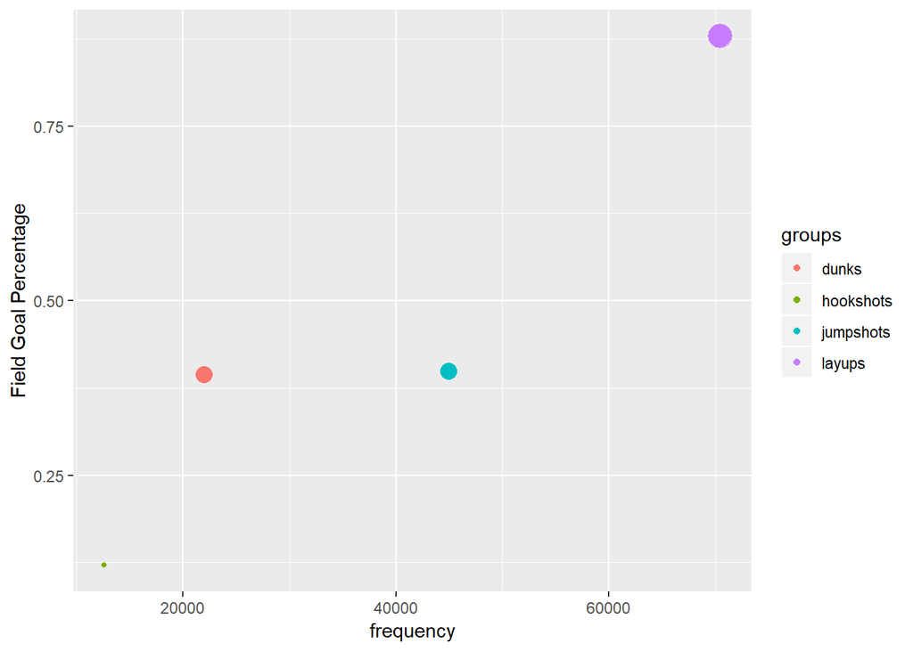

```r
table9 <- table9 %>% mutate(expected_efficiency = ((efficiency*frequency))/50000)
table9$groups <- with(table9, ifelse(action_type %in% dunks, "dunks",
                               ifelse(action_type %in% layups, "layups",
                                      ifelse(action_type %in% hookshots, "hookshots",
                                             ifelse(action_type %in% jumpshots, "jumpshots", "other")))))

table10 <- as.data.frame(aggregate(expected_efficiency ~ groups, sum, data=table9))
table11 <- as.data.frame(aggregate(frequency~groups, sum, data=table9))
table12 <- merge(table10, table11, by='groups')

ggplot(data=table12, aes(x=frequency, y=expected_efficiency, color=groups)) + geom_point(aes(size=expected_efficiency)) + guides(size=FALSE) +
  ylab("Field Goal Percentage")
```

### Q2: Is a team’s efficiency of a team attributed to the most common action types in an NBA offense?

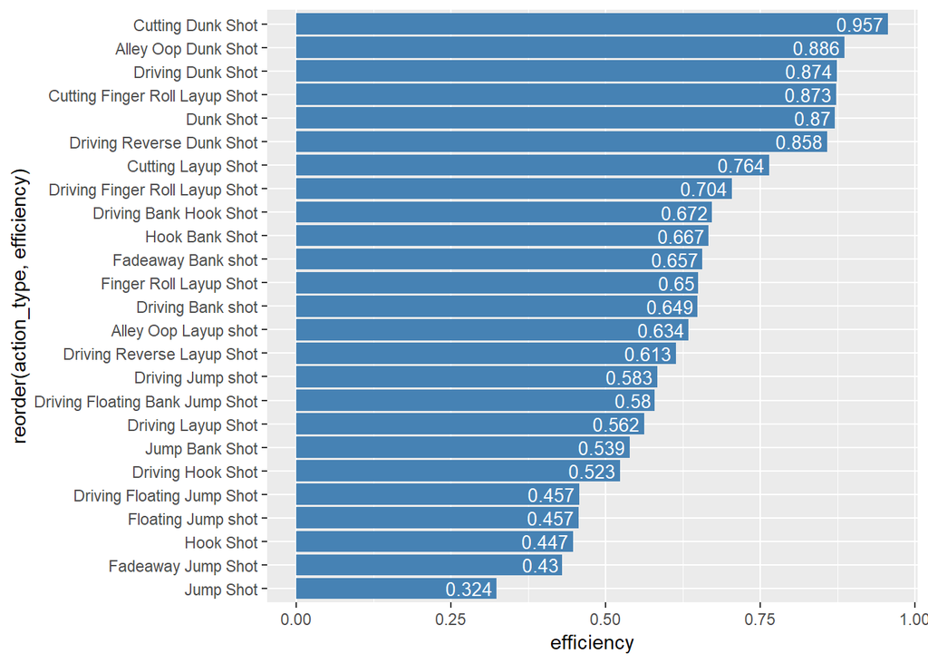

```r
table <- aggregate(nba$shot_made_flag, list(nba$action_type), mean)
table2 <- data.frame(table)
names(table2) <- c("action_type", "efficiency")


actiontype_plot <- ggplot(data = table2, aes(x= reorder(action_type, efficiency), y=efficiency)) + geom_bar(stat="identity", fill="Steelblue") + coord_flip() +
  geom_text(aes(label=round(efficiency,digits = 3)), hjust=1.1, color="white", size = 3.5)
actiontype_plot
```

```r
#
```

# Orator: Chris Chung

### Q1: Do the shots missed/made earlier in a game affect the types of shots taken later in a game?

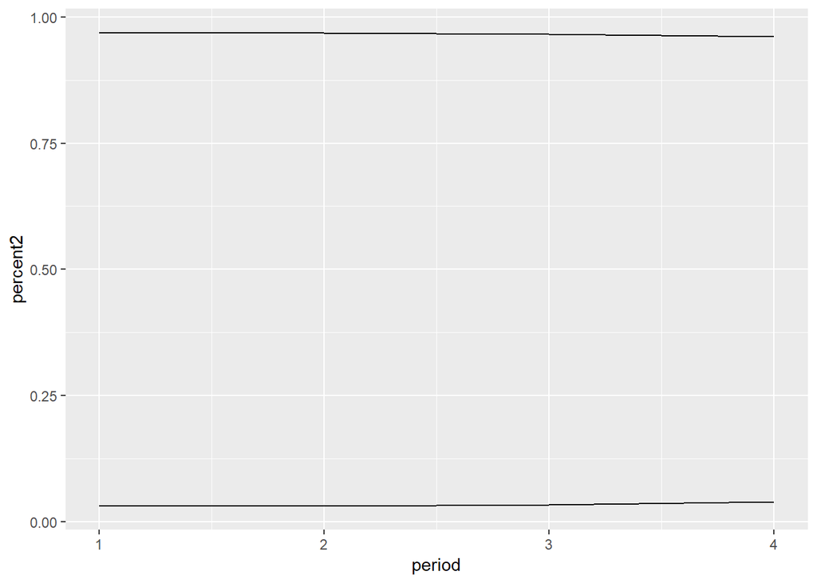

```r
NBA_data <- sav

NBA_shots<-NBA_data %>% group_by(period) %>% summarize(n=n(),n2=sum(shot_type=="2PT Field Goal"),n3=sum(shot_type=="3PT Field Goal"),percent2=sum(shot_type=="2PT Field Goal")/n,percent3=sum(shot_type=="3PT Field Goal")/n) %>% filter(period<=4)
ggplot(NBA_shots)+
  geom_line(aes(x=period,y=percent2))+
  geom_line(aes(x=period,y=percent3))
```

```r
for(i in 2:nrow(NBA_shots)){
    NBA_shots$change2[i]=NBA_shots$percent2[i]-NBA_shots$percent2[i-1]
    NBA_shots$change3[i]=NBA_shots$percent3[i]-NBA_shots$percent3[i-1]
}
NBA_shots
```

```
## # A tibble: 4 x 8
##   period     n    n2    n3 percent2 percent3    change2   change3
##    <int> <int> <int> <int>    <dbl>    <dbl>      <dbl>     <dbl>
## 1      1 38933 37747  1186    0.970   0.0305  NA        NA
## 2      2 38113 36921  1192    0.969   0.0313  -0.000813  0.000813
## 3      3 36176 34961  1215    0.966   0.0336  -0.00231   0.00231
## 4      4 35774 34385  1389    0.961   0.0388  -0.00524   0.00524
```

### Q2: How indicative of shooting percentage is a player’s shot selection?

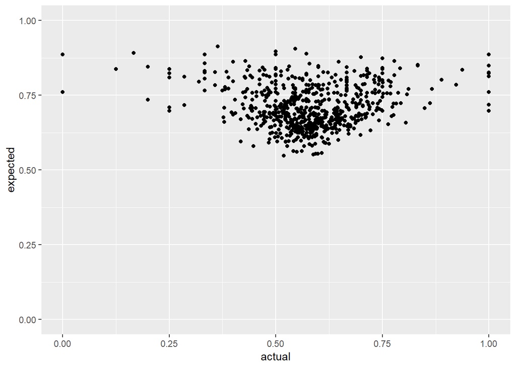

```r
NBA_selection<-NBA_data %>% group_by(action_type) %>% summarize(n=n(),percent=sum(shot_made_flag)/n)
expected_percent<-function(percent,n){
  exp=0
  for(i in 1:length(n)){
    exp=exp+n[i]/sum(n)*percent[i]
  }
  return(exp)
}
expected=NULL
actual=NULL
for(i in 1:length(unique(NBA_data$name))){
  temp=NBA_data %>% filter(name==unique(NBA_data$name)[i]) %>% group_by(action_type) %>% summarize(n=n(),percent=sum(shot_made_flag)/n)
  expected[i]=expected_percent(NBA_selection$percent,temp$n)
  actual[i]=expected_percent(temp$percent,temp$n)
}
ggplot()+
  geom_point(aes(x=actual,y=expected))+
  ylim(0,1)
```

# Deliverer: Ted Henson

### Q1: Can you predict a team’s offensive or defensive efficiency based on the type of shots they take or allow?

```r
library(readr)
library(tidyverse)
setwd("~/analytics")
sav16  <- read_csv("nba_savant 2015-16.csv", na = c(""))
sav17 <- read_csv("nba_savant 2016-17.csv", na = c(""))
sav18  <- read_csv("nba_savant 2017-18.csv", na = c(""))
sav16$year <- 16
sav17$year <- 17
sav18$year <- 18


#
# levels18 <- unique(sav18$action_type)
#
# levels17 <- unique(sav17$action_type)
#
# notinlevels <- levels16[which(!(levels16 %in% levels18))]
# notinlevels


sav <- rbind(sav16, sav17, sav18)

nba.com16 <- read_csv("nba.com 2015-16.csv")
nba.com17 <- read_csv("nba.com 2016-17.csv")
nba.com18 <- read_csv("nba.com 2017-18.csv")
nba.com16$year <- 16
nba.com17$year <- 17
nba.com18$year <- 18


nba.com <- rbind(nba.com16, nba.com17, nba.com18)


names(nba.com)[1] <- "team_name"

nba.com$team_name <- gsub("LA Clippers", "Los Angeles Clippers", nba.com$team_name)
sav$team_name <- gsub("LA Clippers", "Los Angeles Clippers", sav$team_name)

sav$opponent <- gsub("LA Clippers", "Los Angeles Clippers", sav$opponent)


# nba <- rbind(nba2017, nba2016)


library(tidyverse)

nba <- sav


#shot_types <- nba %>% group_by(action_type) %>% summarise(pct = mean(shot_made_flag), number = n())

is.three <- nba$shot_type

index <- which(colnames(nba) == 'shot_type')

nba <- nba[, -c(index)]

nba$action_type <- paste(nba$action_type, is.three, sep = " ")

teamsoff <- nba %>% group_by(team_name, year, action_type) %>% summarise(number = n())

# offnames <- unique(teamsoff$team_name)
#
# defnames <- unique(teamsdef$team_name)
#
# notinlevels <- offnames[which(!(offnames %in% defnames))]
# notinlevels




teamsoff <- teamsoff %>% spread(key = action_type, value = number, fill = 0)

teamsoff[,3:ncol(teamsoff)] <- (teamsoff[,3:ncol(teamsoff)] / rowSums(teamsoff[,3:ncol(teamsoff)])) * 100

#
# divider <- function(x, totaloffshots){
#
#  return((x / totaloffshots) * 100)
# }
#
# teamsoff[,3:ncol(teamsoff)] <- apply(teamsoff[,3:ncol(teamsoff)], MARGIN = 1, FUN = divider)
#



names(teamsoff)[1] <- 'team'




# teams[, 2:end] <- 100* teams[, 2:end]/rowSums(teams[, 2:end])
# teams
# write.csv(teams, file = "NBA 2016-17 teams by shot type.csv", row.names = F)



names(nba.com)[1] <- 'team'


nbatotal <- merge(teamsoff, nba.com)

names(nbatotal) <- gsub(" ", "", names(nbatotal))


end <- which(colnames(nbatotal) == 'GP') - 1



good <- apply(nbatotal[,3:end], MARGIN = 2, FUN = max)

big.prop <- good[which(good > 3)]






formula1 <- as.formula(paste("OFFRTG", "~",
                 paste(names(big.prop), collapse = " + "), "+PACE",
                 sep = " "
))

formula1
```

```
## OFFRTG ~ AlleyOopDunkShot2PTFieldGoal + AlleyOopLayupshot2PTFieldGoal +
##     CuttingDunkShot2PTFieldGoal + CuttingLayupShot2PTFieldGoal +
##     DrivingBankshot2PTFieldGoal + DrivingDunkShot2PTFieldGoal +
##     DrivingFingerRollLayupShot2PTFieldGoal + DrivingFloatingBankJumpShot2PTFieldGoal +
##     DrivingFloatingJumpShot2PTFieldGoal + DrivingHookShot2PTFieldGoal +
##     DrivingLayupShot2PTFieldGoal + DrivingReverseLayupShot2PTFieldGoal +
##     DunkShot2PTFieldGoal + FadeawayJumpShot2PTFieldGoal + FingerRollLayupShot2PTFieldGoal +
##     FloatingJumpshot2PTFieldGoal + HookShot2PTFieldGoal + JumpBankShot2PTFieldGoal +
##     JumpShot2PTFieldGoal + JumpShot3PTFieldGoal + PACE
```

```r
library(MASS)
library(rlang)
library(leaps)




fit <- lm(formula1, data=nbatotal)
step <- stepAIC(fit, direction = "both")
```

```
## Start:  AIC=198.16
## OFFRTG ~ AlleyOopDunkShot2PTFieldGoal + AlleyOopLayupshot2PTFieldGoal +
##     CuttingDunkShot2PTFieldGoal + CuttingLayupShot2PTFieldGoal +
##     DrivingBankshot2PTFieldGoal + DrivingDunkShot2PTFieldGoal +
##     DrivingFingerRollLayupShot2PTFieldGoal + DrivingFloatingBankJumpShot2PTFieldGoal +
##     DrivingFloatingJumpShot2PTFieldGoal + DrivingHookShot2PTFieldGoal +
##     DrivingLayupShot2PTFieldGoal + DrivingReverseLayupShot2PTFieldGoal +
##     DunkShot2PTFieldGoal + FadeawayJumpShot2PTFieldGoal + FingerRollLayupShot2PTFieldGoal +
##     FloatingJumpshot2PTFieldGoal + HookShot2PTFieldGoal + JumpBankShot2PTFieldGoal +
##     JumpShot2PTFieldGoal + JumpShot3PTFieldGoal + PACE
##
##                                           Df Sum of Sq    RSS    AIC
## <none>                                                 499.07 198.16
## - DrivingDunkShot2PTFieldGoal              1    11.667 510.74 198.24
## - PACE                                     1    17.083 516.15 199.19
## - FingerRollLayupShot2PTFieldGoal          1    22.259 521.33 200.09
## - AlleyOopLayupshot2PTFieldGoal            1    22.403 521.47 200.12
## - CuttingDunkShot2PTFieldGoal              1    26.836 525.90 200.88
## - JumpShot3PTFieldGoal                     1    30.917 529.99 201.57
## - DrivingFloatingJumpShot2PTFieldGoal      1    33.455 532.52 202.00
## - JumpBankShot2PTFieldGoal                 1    44.254 543.32 203.81
## - AlleyOopDunkShot2PTFieldGoal             1    46.142 545.21 204.12
## - DrivingReverseLayupShot2PTFieldGoal      1    49.456 548.53 204.67
## - DunkShot2PTFieldGoal                     1    61.634 560.70 206.64
## - DrivingFingerRollLayupShot2PTFieldGoal   1    62.962 562.03 206.86
## - CuttingLayupShot2PTFieldGoal             1    62.976 562.05 206.86
## - FadeawayJumpShot2PTFieldGoal             1    69.763 568.83 207.94
## - FloatingJumpshot2PTFieldGoal             1    76.068 575.14 208.93
## - DrivingHookShot2PTFieldGoal              1    78.580 577.65 209.32
## - DrivingLayupShot2PTFieldGoal             1    81.972 581.04 209.85
## - HookShot2PTFieldGoal                     1    83.040 582.11 210.02
## - JumpShot2PTFieldGoal                     1    97.227 596.30 212.18
## - DrivingFloatingBankJumpShot2PTFieldGoal  1   109.142 608.21 213.96
## - DrivingBankshot2PTFieldGoal              1   113.793 612.86 214.65
```

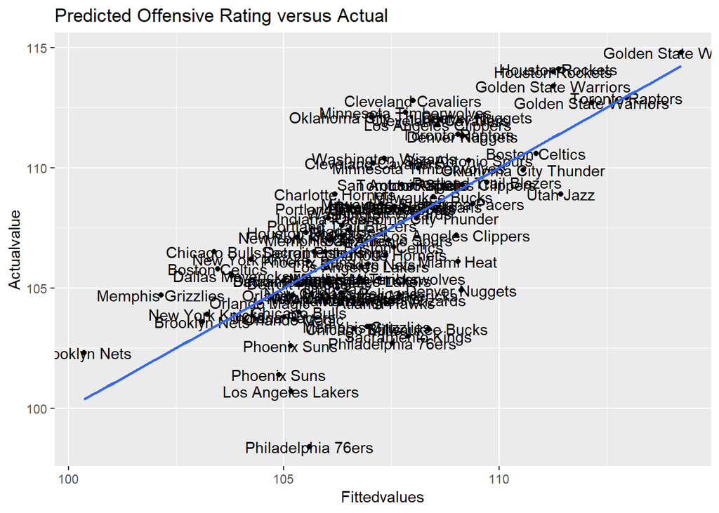

```r
ggplot(nbatotal, aes(step$fitted.values, nbatotal$OFFRTG, label = team)) +
  geom_point() +
  geom_text() +
  geom_smooth(method = "lm", se = FALSE) +
  xlab ("Fittedvalues") +
  ylab ("Actualvalue") +
  ggtitle("Predicted Offensive Rating versus Actual")
```

```r
#
```

### Q2: Does a team’s pace of play correlate with a team’s efficiency?

```r
setwd("~/analytics")


nba.com16 <- read_csv("nba.com 2015-16.csv")
nba.com17 <- read_csv("nba.com 2016-17.csv")
nba.com18 <- read_csv("nba.com 2017-18.csv")
```

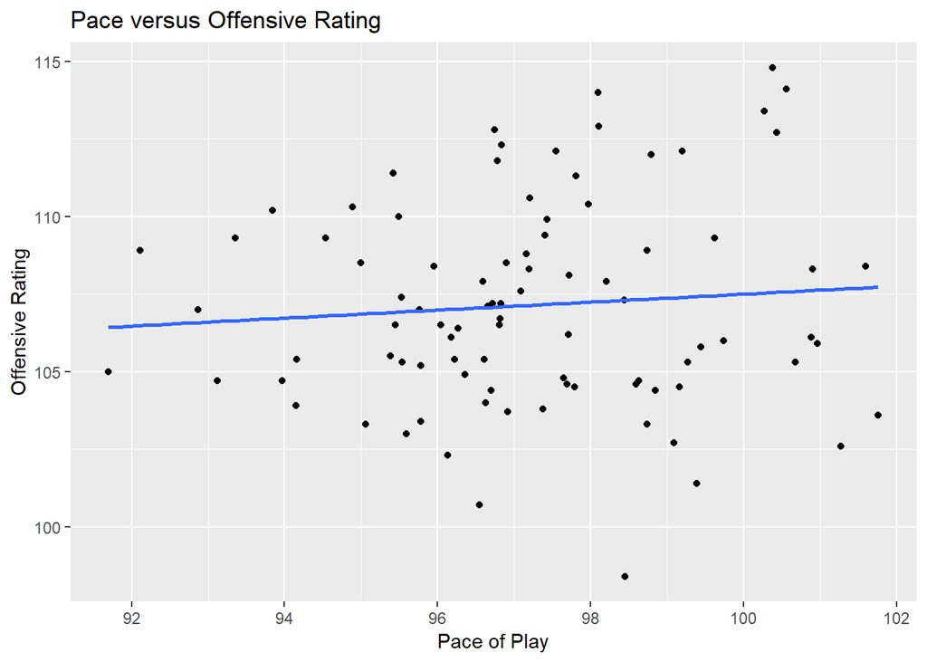

```r
nba.com16$year <- 16
nba.com17$year <- 17
nba.com18$year <- 18


nba.com <- rbind(nba.com16, nba.com17, nba.com18)


ggplot(nba.com, aes(PACE, OFFRTG, label = TEAM))+
  geom_point() +
  geom_smooth(method = "lm", se = FALSE) +
  xlab ("Pace of Play") +
  ylab ("Offensive Rating") +
  ggtitle("Pace versus Offensive Rating")
```

```r
#
```

# Follow-up Questions

### New Questions Based Off Initial Investigation

- Q1: Is there a statistical difference between the change in field goal percantage over time for twos and threes?
- Q2: Can you predict a team’s net efficiency based on the type of and quantity of shots they take and allow?
- Q3: Are certain team’s more efficient in certain quarters than others?
- Q4: Do certain certain shots efficiency vary more by volume than others?
- Q5: Can we predict a player’s offensive rating based on the types he takes?

### Investigation of Follow-up Questions

Can you predict a team’s net efficiency based on the type of and quantity of shots they take and allow?

```r
library(readr)
library(tidyverse)
setwd("~/analytics")
sav16  <- read_csv("nba_savant 2015-16.csv", na = c(""))
sav17 <- read_csv("nba_savant 2016-17.csv", na = c(""))
sav18  <- read_csv("nba_savant 2017-18.csv", na = c(""))
sav16$year <- 16
sav17$year <- 17
sav18$year <- 18


#
# levels18 <- unique(sav18$action_type)
#
# levels17 <- unique(sav17$action_type)
#
# notinlevels <- levels16[which(!(levels16 %in% levels18))]
# notinlevels


sav <- rbind(sav16, sav17, sav18)

nba.com16 <- read_csv("nba.com 2015-16.csv")
nba.com17 <- read_csv("nba.com 2016-17.csv")
nba.com18 <- read_csv("nba.com 2017-18.csv")
nba.com16$year <- 16
nba.com17$year <- 17
nba.com18$year <- 18


nba.com <- rbind(nba.com16, nba.com17, nba.com18)


names(nba.com)[1] <- "team_name"

nba.com$team_name <- gsub("LA Clippers", "Los Angeles Clippers", nba.com$team_name)
sav$team_name <- gsub("LA Clippers", "Los Angeles Clippers", sav$team_name)

sav$opponent <- gsub("LA Clippers", "Los Angeles Clippers", sav$opponent)


# nba <- rbind(nba2017, nba2016)


library(tidyverse)

nba <- sav


#shot_types <- nba %>% group_by(action_type) %>% summarise(pct = mean(shot_made_flag), number = n())

is.three <- nba$shot_type

index <- which(colnames(nba) == 'shot_type')

nba <- nba[, -c(index)]

nba$action_type <- paste(nba$action_type, is.three, sep = " ")

teamsoff <- nba %>% group_by(team_name, year, action_type) %>% summarise(number = n())
teamsdef <- nba %>% group_by(opponent, year, action_type) %>% summarise(number = n())




# offnames <- unique(teamsoff$team_name)
#
# defnames <- unique(teamsdef$team_name)
#
# notinlevels <- offnames[which(!(offnames %in% defnames))]
# notinlevels




teamsoff <- teamsoff %>% spread(key = action_type, value = number, fill = 0)
teamsoff
```

```
## # A tibble: 90 x 38
## # Groups:   team_name, year [90]
##    team_name  year `Alley Oop Dunk~ `Alley Oop Layu~ `Cutting Dunk S~
##    <chr>     <dbl>            <dbl>            <dbl>            <dbl>
##  1 Atlanta ~    16               34               33               34
##  2 Atlanta ~    17               89               33               36
##  3 Atlanta ~    18               53               23               76
##  4 Boston C~    16                9               38               34
##  5 Boston C~    17               15               27               54
##  6 Boston C~    18               48               31               69
##  7 Brooklyn~    16               23               21               19
##  8 Brooklyn~    17                8               15               40
##  9 Brooklyn~    18               24                9              115
## 10 Charlott~    16               11               17               41
## # ... with 80 more rows, and 33 more variables: `Cutting Finger Roll Layup
## #   Shot 2PT Field Goal` <dbl>, `Cutting Layup Shot 2PT Field Goal` <dbl>,
## #   `Driving Bank Hook Shot 2PT Field Goal` <dbl>, `Driving Bank Hook Shot
## #   3PT Field Goal` <dbl>, `Driving Bank shot 2PT Field Goal` <dbl>,
## #   `Driving Bank shot 3PT Field Goal` <dbl>, `Driving Dunk Shot 2PT Field
## #   Goal` <dbl>, `Driving Finger Roll Layup Shot 2PT Field Goal` <dbl>,
## #   `Driving Floating Bank Jump Shot 2PT Field Goal` <dbl>, `Driving
## #   Floating Bank Jump Shot 3PT Field Goal` <dbl>, `Driving Floating Jump
## #   Shot 2PT Field Goal` <dbl>, `Driving Floating Jump Shot 3PT Field
## #   Goal` <dbl>, `Driving Hook Shot 2PT Field Goal` <dbl>, `Driving Hook
## #   Shot 3PT Field Goal` <dbl>, `Driving Jump shot 2PT Field Goal` <dbl>,
## #   `Driving Layup Shot 2PT Field Goal` <dbl>, `Driving Reverse Dunk Shot
## #   2PT Field Goal` <dbl>, `Driving Reverse Layup Shot 2PT Field
## #   Goal` <dbl>, `Dunk Shot 2PT Field Goal` <dbl>, `Fadeaway Bank shot 2PT
## #   Field Goal` <dbl>, `Fadeaway Bank shot 3PT Field Goal` <dbl>,
## #   `Fadeaway Jump Shot 2PT Field Goal` <dbl>, `Fadeaway Jump Shot 3PT
## #   Field Goal` <dbl>, `Finger Roll Layup Shot 2PT Field Goal` <dbl>,
## #   `Floating Jump shot 2PT Field Goal` <dbl>, `Floating Jump shot 3PT
## #   Field Goal` <dbl>, `Hook Bank Shot 2PT Field Goal` <dbl>, `Hook Shot
## #   2PT Field Goal` <dbl>, `Hook Shot 3PT Field Goal` <dbl>, `Jump Bank
## #   Shot 2PT Field Goal` <dbl>, `Jump Bank Shot 3PT Field Goal` <dbl>,
## #   `Jump Shot 2PT Field Goal` <dbl>, `Jump Shot 3PT Field Goal` <dbl>
```

```r
teamsdef <- teamsdef %>% spread(key = action_type, value = number, fill = 0)
teamsdef
```

```
## # A tibble: 90 x 38
## # Groups:   opponent, year [90]
##    opponent  year `Alley Oop Dunk~ `Alley Oop Layu~ `Cutting Dunk S~
##    <chr>    <dbl>            <dbl>            <dbl>            <dbl>
##  1 Atlanta~    16               36               27               41
##  2 Atlanta~    17               29               21               47
##  3 Atlanta~    18               42               23               62
##  4 Boston ~    16               25               24               44
##  5 Boston ~    17               48               24               68
##  6 Boston ~    18               49               29               85
##  7 Brookly~    16               58               25               62
##  8 Brookly~    17               49               25               76
##  9 Brookly~    18               44               35               78
## 10 Charlot~    16               38               26               27
## # ... with 80 more rows, and 33 more variables: `Cutting Finger Roll Layup
## #   Shot 2PT Field Goal` <dbl>, `Cutting Layup Shot 2PT Field Goal` <dbl>,
## #   `Driving Bank Hook Shot 2PT Field Goal` <dbl>, `Driving Bank Hook Shot
## #   3PT Field Goal` <dbl>, `Driving Bank shot 2PT Field Goal` <dbl>,
## #   `Driving Bank shot 3PT Field Goal` <dbl>, `Driving Dunk Shot 2PT Field
## #   Goal` <dbl>, `Driving Finger Roll Layup Shot 2PT Field Goal` <dbl>,
## #   `Driving Floating Bank Jump Shot 2PT Field Goal` <dbl>, `Driving
## #   Floating Bank Jump Shot 3PT Field Goal` <dbl>, `Driving Floating Jump
## #   Shot 2PT Field Goal` <dbl>, `Driving Floating Jump Shot 3PT Field
## #   Goal` <dbl>, `Driving Hook Shot 2PT Field Goal` <dbl>, `Driving Hook
## #   Shot 3PT Field Goal` <dbl>, `Driving Jump shot 2PT Field Goal` <dbl>,
## #   `Driving Layup Shot 2PT Field Goal` <dbl>, `Driving Reverse Dunk Shot
## #   2PT Field Goal` <dbl>, `Driving Reverse Layup Shot 2PT Field
## #   Goal` <dbl>, `Dunk Shot 2PT Field Goal` <dbl>, `Fadeaway Bank shot 2PT
## #   Field Goal` <dbl>, `Fadeaway Bank shot 3PT Field Goal` <dbl>,
## #   `Fadeaway Jump Shot 2PT Field Goal` <dbl>, `Fadeaway Jump Shot 3PT
## #   Field Goal` <dbl>, `Finger Roll Layup Shot 2PT Field Goal` <dbl>,
## #   `Floating Jump shot 2PT Field Goal` <dbl>, `Floating Jump shot 3PT
## #   Field Goal` <dbl>, `Hook Bank Shot 2PT Field Goal` <dbl>, `Hook Shot
## #   2PT Field Goal` <dbl>, `Hook Shot 3PT Field Goal` <dbl>, `Jump Bank
## #   Shot 2PT Field Goal` <dbl>, `Jump Bank Shot 3PT Field Goal` <dbl>,
## #   `Jump Shot 2PT Field Goal` <dbl>, `Jump Shot 3PT Field Goal` <dbl>
```

```r
teamsoff[,3:ncol(teamsoff)] <- (teamsoff[,3:ncol(teamsoff)] / rowSums(teamsoff[,3:ncol(teamsoff)])) * 100

teamsdef[,3:ncol(teamsdef)] <- (teamsdef[,3:ncol(teamsdef)] / rowSums(teamsdef[,3:ncol(teamsdef)])) * 100

#
# divider <- function(x, totaloffshots){
#
#  return((x / totaloffshots) * 100)
# }
#
# teamsoff[,3:ncol(teamsoff)] <- apply(teamsoff[,3:ncol(teamsoff)], MARGIN = 1, FUN = divider)
#




names(teamsdef)[1] <- 'team'
names(teamsoff)[1] <- 'team'

paster <- function(x){

  return(paste(x, 'off', sep = " "))

}

colnames(teamsoff)[3:ncol(teamsoff)] <- lapply(colnames(teamsoff)[3:ncol(teamsoff)], FUN = paster)



paster <- function(x){

  return(paste(x, 'def', sep = " "))

}

colnames(teamsdef)[3:ncol(teamsdef)] <- lapply(colnames(teamsdef)[3:ncol(teamsdef)], FUN = paster)


teams <- merge(teamsdef, teamsoff)



# teams[, 2:end] <- 100* teams[, 2:end]/rowSums(teams[, 2:end])
# teams
# write.csv(teams, file = "NBA 2016-17 teams by shot type.csv", row.names = F)



names(nba.com)[1] <- 'team'


nbatotal <- merge(teams, nba.com)

names(nbatotal) <- gsub(" ", "", names(nbatotal))


end <- which(colnames(nbatotal) == 'GP') - 1



good <- apply(nbatotal[,3:end], MARGIN = 2, FUN = max)

big.prop <- good[which(good > 3)]






formula1 <- as.formula(paste("NETRTG", "~",
                 paste(names(big.prop), collapse = " + "), "+PACE",
                 sep = " "
))

formula1
```

```
## NETRTG ~ AlleyOopDunkShot2PTFieldGoaldef + CuttingDunkShot2PTFieldGoaldef +
##     CuttingLayupShot2PTFieldGoaldef + DrivingBankshot2PTFieldGoaldef +
##     DrivingDunkShot2PTFieldGoaldef + DrivingFingerRollLayupShot2PTFieldGoaldef +
##     DrivingFloatingBankJumpShot2PTFieldGoaldef + DrivingFloatingJumpShot2PTFieldGoaldef +
##     DrivingHookShot2PTFieldGoaldef + DrivingLayupShot2PTFieldGoaldef +
##     DrivingReverseLayupShot2PTFieldGoaldef + DunkShot2PTFieldGoaldef +
##     FadeawayJumpShot2PTFieldGoaldef + FloatingJumpshot2PTFieldGoaldef +
##     HookShot2PTFieldGoaldef + JumpBankShot2PTFieldGoaldef + JumpShot2PTFieldGoaldef +
##     JumpShot3PTFieldGoaldef + AlleyOopDunkShot2PTFieldGoaloff +
##     AlleyOopLayupshot2PTFieldGoaloff + CuttingDunkShot2PTFieldGoaloff +
##     CuttingLayupShot2PTFieldGoaloff + DrivingBankshot2PTFieldGoaloff +
##     DrivingDunkShot2PTFieldGoaloff + DrivingFingerRollLayupShot2PTFieldGoaloff +
##     DrivingFloatingBankJumpShot2PTFieldGoaloff + DrivingFloatingJumpShot2PTFieldGoaloff +
##     DrivingHookShot2PTFieldGoaloff + DrivingLayupShot2PTFieldGoaloff +
##     DrivingReverseLayupShot2PTFieldGoaloff + DunkShot2PTFieldGoaloff +
##     FadeawayJumpShot2PTFieldGoaloff + FingerRollLayupShot2PTFieldGoaloff +
##     FloatingJumpshot2PTFieldGoaloff + HookShot2PTFieldGoaloff +
##     JumpBankShot2PTFieldGoaloff + JumpShot2PTFieldGoaloff + JumpShot3PTFieldGoaloff +
##     PACE
```

```r
library(MASS)

library(rlang)


library(leaps)



set.seed(1110)
library(caTools)

sample = sample.split(nbatotal$team, SplitRatio = .8)
train = subset(nbatotal, sample == TRUE)
test  = subset(nbatotal, sample == FALSE)



fit <- lm(formula1, data=train)
step <- stepAIC(fit, direction = "both")
```

```
## Start:  AIC=142.12
## NETRTG ~ AlleyOopDunkShot2PTFieldGoaldef + CuttingDunkShot2PTFieldGoaldef +
##     CuttingLayupShot2PTFieldGoaldef + DrivingBankshot2PTFieldGoaldef +
##     DrivingDunkShot2PTFieldGoaldef + DrivingFingerRollLayupShot2PTFieldGoaldef +
##     DrivingFloatingBankJumpShot2PTFieldGoaldef + DrivingFloatingJumpShot2PTFieldGoaldef +
##     DrivingHookShot2PTFieldGoaldef + DrivingLayupShot2PTFieldGoaldef +
##     DrivingReverseLayupShot2PTFieldGoaldef + DunkShot2PTFieldGoaldef +
##     FadeawayJumpShot2PTFieldGoaldef + FloatingJumpshot2PTFieldGoaldef +
##     HookShot2PTFieldGoaldef + JumpBankShot2PTFieldGoaldef + JumpShot2PTFieldGoaldef +
##     JumpShot3PTFieldGoaldef + AlleyOopDunkShot2PTFieldGoaloff +
##     AlleyOopLayupshot2PTFieldGoaloff + CuttingDunkShot2PTFieldGoaloff +
##     CuttingLayupShot2PTFieldGoaloff + DrivingBankshot2PTFieldGoaloff +
##     DrivingDunkShot2PTFieldGoaloff + DrivingFingerRollLayupShot2PTFieldGoaloff +
##     DrivingFloatingBankJumpShot2PTFieldGoaloff + DrivingFloatingJumpShot2PTFieldGoaloff +
##     DrivingHookShot2PTFieldGoaloff + DrivingLayupShot2PTFieldGoaloff +
##     DrivingReverseLayupShot2PTFieldGoaloff + DunkShot2PTFieldGoaloff +
##     FadeawayJumpShot2PTFieldGoaloff + FingerRollLayupShot2PTFieldGoaloff +
##     FloatingJumpshot2PTFieldGoaloff + HookShot2PTFieldGoaloff +
##     JumpBankShot2PTFieldGoaloff + JumpShot2PTFieldGoaloff + JumpShot3PTFieldGoaloff +
##     PACE
##
##                                              Df Sum of Sq    RSS    AIC
## - JumpShot2PTFieldGoaldef                     1    0.0002 168.96 140.12
## - DrivingFingerRollLayupShot2PTFieldGoaloff   1    0.0089 168.97 140.12
## - DunkShot2PTFieldGoaloff                     1    0.0115 168.97 140.12
## - JumpShot2PTFieldGoaloff                     1    0.0396 169.00 140.13
## - DrivingReverseLayupShot2PTFieldGoaldef      1    0.0656 169.03 140.14
## - CuttingDunkShot2PTFieldGoaloff              1    0.0697 169.03 140.15
## - DunkShot2PTFieldGoaldef                     1    0.1535 169.12 140.17
## - DrivingFloatingJumpShot2PTFieldGoaloff      1    0.2006 169.16 140.19
## - CuttingLayupShot2PTFieldGoaloff             1    0.4263 169.39 140.27
## - AlleyOopLayupshot2PTFieldGoaloff            1    0.9506 169.91 140.46
## - AlleyOopDunkShot2PTFieldGoaloff             1    1.2828 170.25 140.57
## - DrivingReverseLayupShot2PTFieldGoaloff      1    1.4319 170.39 140.63
## - DrivingDunkShot2PTFieldGoaldef              1    1.4704 170.43 140.64
## - DrivingLayupShot2PTFieldGoaldef             1    1.5053 170.47 140.65
## - FadeawayJumpShot2PTFieldGoaldef             1    2.5265 171.49 141.01
## - JumpBankShot2PTFieldGoaloff                 1    3.3280 172.29 141.29
## - FloatingJumpshot2PTFieldGoaldef             1    3.4086 172.37 141.32
## - DrivingBankshot2PTFieldGoaloff              1    3.4771 172.44 141.34
```

[output cut: 945 more lines]

```
## - DrivingHookShot2PTFieldGoaldef              1    26.971 210.03 125.17
## - PACE                                        1    31.560 214.62 126.47
## - DrivingHookShot2PTFieldGoaloff              1    33.571 216.63 127.03
## - CuttingLayupShot2PTFieldGoaldef             1    37.872 220.93 128.21
## - AlleyOopDunkShot2PTFieldGoaldef             1    52.465 235.52 132.05
## - DrivingDunkShot2PTFieldGoaloff              1    61.936 245.00 134.41
## - FloatingJumpshot2PTFieldGoaldef             1    64.626 247.69 135.07
## - HookShot2PTFieldGoaldef                     1    67.313 250.37 135.72
## - DrivingFingerRollLayupShot2PTFieldGoaldef   1    69.749 252.81 136.30
## - JumpBankShot2PTFieldGoaldef                 1    75.035 258.10 137.54
## - JumpShot3PTFieldGoaloff                     1   114.326 297.39 146.04
## - FadeawayJumpShot2PTFieldGoaloff             1   128.937 312.00 148.92
## - HookShot2PTFieldGoaloff                     1   176.943 360.00 157.51
## - FloatingJumpshot2PTFieldGoaloff             1   216.074 399.13 163.70
## - DrivingLayupShot2PTFieldGoaloff             1   261.913 444.97 170.22
```

```r
library(broom)

# create a dataframe frm model's output
tm = tidy(step)

terms <- tm$term[tm$p.value < 0.05]

terms <- terms[-c(1)]

formula1 <- as.formula(paste("NETRTG", "~",
                             paste(terms, collapse = " + "),
                             sep = ""
))

fit <- lm(formula1, data=train)
step <- stepAIC(fit, direction = "both")
```

```
## Start:  AIC=141.3
## NETRTG ~ AlleyOopDunkShot2PTFieldGoaldef + CuttingLayupShot2PTFieldGoaldef +
##     DrivingFingerRollLayupShot2PTFieldGoaldef + DrivingHookShot2PTFieldGoaldef +
##     FloatingJumpshot2PTFieldGoaldef + HookShot2PTFieldGoaldef +
##     JumpBankShot2PTFieldGoaldef + DrivingDunkShot2PTFieldGoaloff +
##     DrivingHookShot2PTFieldGoaloff + DrivingLayupShot2PTFieldGoaloff +
##     FadeawayJumpShot2PTFieldGoaloff + FloatingJumpshot2PTFieldGoaloff +
##     HookShot2PTFieldGoaloff + JumpShot3PTFieldGoaloff + PACE
##
##                                             Df Sum of Sq    RSS    AIC
## - DrivingHookShot2PTFieldGoaldef             1     1.753 372.66 139.58
## - DrivingDunkShot2PTFieldGoaloff             1     3.618 374.53 139.88
## - DrivingFingerRollLayupShot2PTFieldGoaldef  1    11.323 382.23 141.10
## <none>                                                   370.91 141.30
## - DrivingHookShot2PTFieldGoaloff             1    16.947 387.86 141.98
## - JumpBankShot2PTFieldGoaldef                1    36.040 406.95 144.86
## - PACE                                       1    45.132 416.04 146.19
## - AlleyOopDunkShot2PTFieldGoaldef            1    47.215 418.12 146.49
## - HookShot2PTFieldGoaldef                    1    56.485 427.39 147.80
## - JumpShot3PTFieldGoaloff                    1    57.634 428.54 147.96
## - CuttingLayupShot2PTFieldGoaldef            1    66.398 437.31 149.18
## - HookShot2PTFieldGoaloff                    1    83.036 453.95 151.42
## - FloatingJumpshot2PTFieldGoaldef            1    95.490 466.40 153.04
## - FadeawayJumpShot2PTFieldGoaloff            1   129.629 500.54 157.28
## - FloatingJumpshot2PTFieldGoaloff            1   137.626 508.54 158.23
## - DrivingLayupShot2PTFieldGoaloff            1   210.399 581.31 166.26
##
## Step:  AIC=139.58
## NETRTG ~ AlleyOopDunkShot2PTFieldGoaldef + CuttingLayupShot2PTFieldGoaldef +
##     DrivingFingerRollLayupShot2PTFieldGoaldef + FloatingJumpshot2PTFieldGoaldef +
##     HookShot2PTFieldGoaldef + JumpBankShot2PTFieldGoaldef + DrivingDunkShot2PTFieldGoaloff +
##     DrivingHookShot2PTFieldGoaloff + DrivingLayupShot2PTFieldGoaloff +
##     FadeawayJumpShot2PTFieldGoaloff + FloatingJumpshot2PTFieldGoaloff +
##     HookShot2PTFieldGoaloff + JumpShot3PTFieldGoaloff + PACE
##
##                                             Df Sum of Sq    RSS    AIC
## - DrivingDunkShot2PTFieldGoaloff             1     4.399 377.06 138.28
## <none>                                                   372.66 139.58
## - DrivingFingerRollLayupShot2PTFieldGoaldef  1    12.882 385.55 139.62
## - DrivingHookShot2PTFieldGoaloff             1    15.360 388.02 140.00
```

[output cut: 49 more lines]

```
## - DrivingHookShot2PTFieldGoaloff             1    13.659 400.29 137.87
## + DrivingFingerRollLayupShot2PTFieldGoaldef  1     9.565 377.06 138.28
## + DrivingHookShot2PTFieldGoaldef             1     3.646 382.98 139.22
## + DrivingDunkShot2PTFieldGoaloff             1     1.082 385.55 139.62
## - JumpBankShot2PTFieldGoaldef                1    34.428 421.06 140.91
## - PACE                                       1    41.746 428.37 141.94
## - HookShot2PTFieldGoaldef                    1    46.782 433.41 142.64
## - JumpShot3PTFieldGoaloff                    1    58.120 444.75 144.19
## - AlleyOopDunkShot2PTFieldGoaldef            1    63.234 449.86 144.88
## - CuttingLayupShot2PTFieldGoaldef            1    68.466 455.09 145.57
## - FloatingJumpshot2PTFieldGoaldef            1    86.482 473.11 147.90
## - HookShot2PTFieldGoaloff                    1   121.715 508.34 152.21
## - FadeawayJumpShot2PTFieldGoaloff            1   135.044 521.67 153.76
## - FloatingJumpshot2PTFieldGoaloff            1   167.374 554.00 157.37
## - DrivingLayupShot2PTFieldGoaloff            1   260.878 647.51 166.73
```

```r
summary(step)
```

```
##
## Call:
## lm(formula = NETRTG ~ AlleyOopDunkShot2PTFieldGoaldef + CuttingLayupShot2PTFieldGoaldef +
##     FloatingJumpshot2PTFieldGoaldef + HookShot2PTFieldGoaldef +
##     JumpBankShot2PTFieldGoaldef + DrivingHookShot2PTFieldGoaloff +
##     DrivingLayupShot2PTFieldGoaloff + FadeawayJumpShot2PTFieldGoaloff +
##     FloatingJumpshot2PTFieldGoaloff + HookShot2PTFieldGoaloff +
##     JumpShot3PTFieldGoaloff + PACE, data = train)
##
## Residuals:
##    Min     1Q Median     3Q    Max
## -4.959 -1.782  0.159  2.059  6.666
##
## Coefficients:
##                                 Estimate Std. Error t value Pr(>|t|)
## (Intercept)                      96.0751    24.4339   3.932 0.000276 ***
## AlleyOopDunkShot2PTFieldGoaldef  -2.2005     0.7937  -2.773 0.007948 **
## CuttingLayupShot2PTFieldGoaldef  -0.7640     0.2648  -2.885 0.005892 **
## FloatingJumpshot2PTFieldGoaldef   0.7393     0.2280   3.242 0.002183 **
## HookShot2PTFieldGoaldef          -0.6625     0.2778  -2.385 0.021177 *
## JumpBankShot2PTFieldGoaldef       1.0329     0.5049   2.046 0.046396 *
## DrivingHookShot2PTFieldGoaloff   -0.5611     0.4354  -1.289 0.203856
## DrivingLayupShot2PTFieldGoaloff  -0.6557     0.1164  -5.631 9.68e-07 ***
## FadeawayJumpShot2PTFieldGoaloff  -1.0496     0.2591  -4.052 0.000189 ***
## FloatingJumpshot2PTFieldGoaloff  -0.8862     0.1965  -4.511 4.30e-05 ***
## HookShot2PTFieldGoaloff          -0.5335     0.1387  -3.847 0.000360 ***
## JumpShot3PTFieldGoaloff          -0.6760     0.2543  -2.658 0.010707 *
## PACE                             -0.5235     0.2324  -2.253 0.028984 *
## ---
## Signif. codes:  0 '***' 0.001 '**' 0.01 '*' 0.05 '.' 0.1 ' ' 1
##
## Residual standard error: 2.868 on 47 degrees of freedom
## Multiple R-squared:  0.7043, Adjusted R-squared:  0.6288
## F-statistic: 9.327 on 12 and 47 DF,  p-value: 7.53e-09
```

```r
please <- predict(step, newdata = test)

crossscor <- cor(test$NETRTG, please)
crossscor
```

```
## [1] 0.3967947
```

```r
error <- test$NETRTG - please


lm_error <- sqrt(mean(error^2))
lm_error
```

```
## [1] 5.075452
```

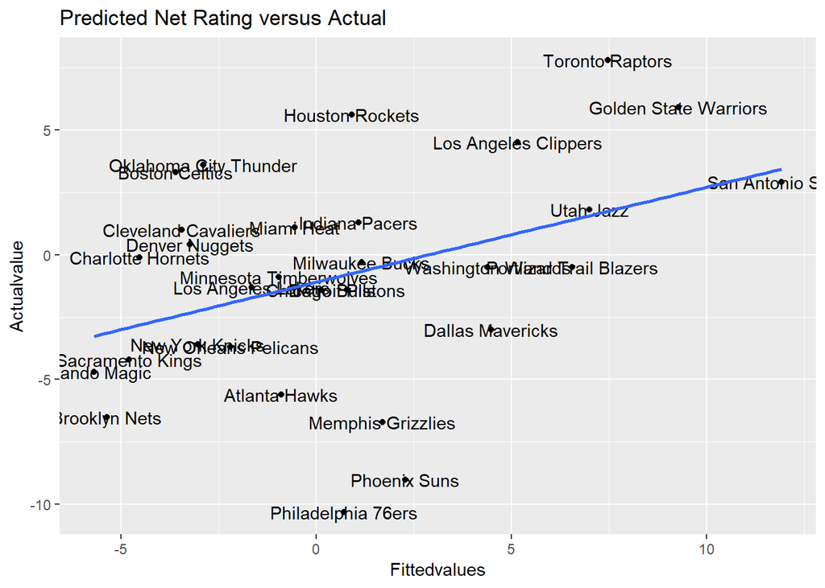

```r
ggplot(test, aes(please, test$NETRTG, label = team)) +
  geom_point() +
  geom_text() +
  geom_smooth(method = "lm", se = FALSE) +
  xlab ("Fittedvalues") +
  ylab ("Actualvalue") +
  ggtitle("Predicted Net Rating versus Actual")
```

```r
#
#
#
# library(e1071)
#
# #Fit a model. The function syntax is very similar to lm function
#
#
#
# model_svm <- svm(formula1, nbatotal)
#
#
#
# #Use the predictions on the data
#
# pred <- predict(model_svm, nbatotal)
#
# error_2 <- nbatotal$NETRTG - pred
#
#
# svm_error <- sqrt(mean(error_2^2))
#


#
```

Do shots taken in different periods have a different percentage of going in?

```r
twosandthrees <- sav %>% group_by(period) %>% summarise(pct = mean(shot_made_flag))

threepointers <- sav %>% filter(shot_type == '3PT Field Goal') %>% group_by(period) %>% summarise(pct = mean(shot_made_flag))

twopointers <- sav %>% filter(shot_type == '2PT Field Goal') %>%  group_by(period) %>% summarise(pct = mean(shot_made_flag))



twosandthrees
```

```
## # A tibble: 8 x 2
##   period   pct
##    <int> <dbl>
## 1      1 0.595
## 2      2 0.601
## 3      3 0.596
## 4      4 0.600
## 5      5 0.556
## 6      6 0.587
## 7      7 0.5
## 8      8 0.444
```

```r
chisq.test(twosandthrees)
```

```
##
##  Pearson's Chi-squared test
##
## data:  twosandthrees
## X-squared = 2.1003, df = 7, p-value = 0.9541
```

```r
chisq.test(threepointers)
```

```
##
##  Pearson's Chi-squared test
##
## data:  threepointers
## X-squared = 1.4086, df = 5, p-value = 0.9234
```

```r
chisq.test(twopointers)
```

```
##
##  Pearson's Chi-squared test
##
## data:  twopointers
## X-squared = 2.1258, df = 7, p-value = 0.9526
```

```r
#
```

# Summary

Most of our questions concerned how the type of shots teams took correlated with a team’s efficiency. The questions concerning efficiency and how a shot’s chances of going in over the course of game lead to our follow up questions. We were surprised that 3 pointers were less than 10% of all shots as shown by our table in the initial questions. Regarding a shot’s preference and its efficiency, when the shots were classified into four groups based on their types, there was a moderately strong, positive relationship between the shots that players prefer and their efficiencies. We initially expected that the most efficient action types in an offense would be dunks and layup shots based on the graph on action type and efficiency. However, we were surprised to see that jumpshots and dunks have a similar expected efficiency in an NBA offense, and the expected efficiency of layups was much higher than other types of shots. Such correlation has led us to investigate more in depth on how the quantity of shots influences a team’s net efficiency.